# Computation Statistics - first assignment. A: Density Estimation

```r
#Read required libraries
library(ggplot2)          # For plotting
library(bench)            # For benchmarking
library(dplyr)            # For data manipulation
library(microbenchmark)   # For benchmarking code
library(Rfast)            # For fast matrix operations
library(grid)             # For arranging plots
library(gridExtra)        # For arranging plots
library(testthat)         # For testing
library(MASS)             # For ucv
library(parallel)         # For parallel processing
library(doParallel)       # For parallel processing
library(CSwR)
library(Matrix)           # For matrix operations and sparse matrices


# Source relevant scripts
source("Functions.R")
source("GaussianEnvelope.R")
```

Read poisson data

```
##   z          x
## 1 1 1.06239965
## 2 2 0.52017672
## 3 3 0.08300746
## 4 1 1.72165953
## 5 2 0.13635255
## 6 3 0.49121322
```

```
## [1] 100   2
```

# What is rejection sampling and why to use

Sample from complex distributions by sampling from a simpler distribution and rejecting samples that do not resemble the target distribution.

# Brief theoretical introduction

Rejection sampling builds on the idea, that we can sample from a distribution $f(x)$ by sampling from a proposed distribution $g(x)$ and then reject the samples from $g(x)$ that does not resemble $f(x)$. This is based on some criteria.

To be more specific. Let $f(x)$ be the target distribution and $g(x)$ be the proposal distribution such that

$$g(x) = 0 \Rightarrow f(x) =
0$$

# Implementation of Gaussian envelope

The purpose is to sample from the distribution

$$f(x) \propto \prod_{i = 1}^{100}
\exp(yz_ix_i - \exp(yx_i)), \quad y \geq 0$$
using a Gaussian envelope of $f$. That is, using a proposal distribution $g(x) \sim \mathcal{N}(\mu, \sigma^2)$.

In order to get an efficient algorithm we should choose suitable values for $\mu$ and $\sigma$ as well as a proper value of $\alpha$. Note that instead of choosing a gaussian density for $g(x)$ we can find a function that is proportional to $g(x)$. In particular, for some constants $c$ and $d$ we let

$$q(x) = \frac{f(x)}{c} = \prod_{i =
1}^{100} \exp(yz_ix_i - \exp(yx_i)), \quad y \geq 0$$
and
$$p(x) = \frac{g(x)}{d}$$
.

We can then choose

$$\alpha' = \frac{c}{d}
\alpha$$

such that

$$u \leq \alpha \frac{f(x)}{g(x)} \iff u
\leq \alpha' \frac{q(x)}{p(x)}$$
We already know $q(x)$ and we can pick any function $p(x)$ that is proportional to $g(x)$ including $g(x)$ itself such that $d=1$ and $\alpha' = \alpha c$. The objective is now to find a suitable $\alpha'$ such that the rejection probability is small. We can choose $\alpha'$ to be the number
$$\alpha' = \inf_{x:q(x) > 0}
\frac{p(x)}{q(x)} > 0$$
Before we determine $\alpha'$ we should choose $\mu$ and $\sigma$ such that the proposal distribution $g(x)$ covers the target distribution $f(x)$.

Look into `Vectorize() = arg max f_dens1(x)` $\mu^{opt}$ parallelization as samples are independent

Vertical scaling: Scaling individual code pieces making them more efficient Horizontal scaling: Paralleling the code

xaringan presentation tool

gradually implement things in Cpp

When using & you pass a memory reference and not a copy of the object. This is useful when you want to change the object in the function.

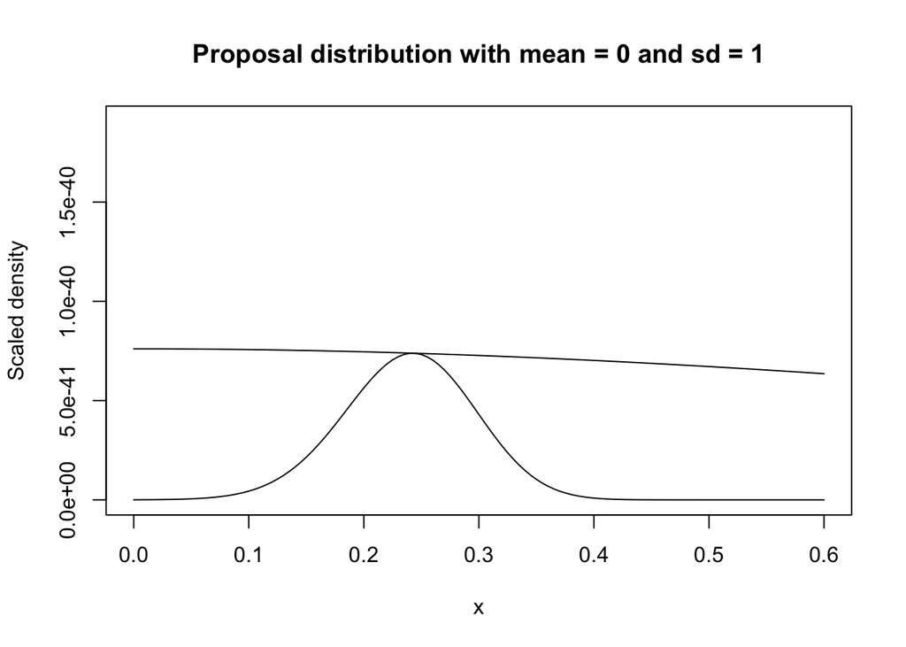

```r
alpha_prime <- optimize(f = function(y) proportion_function(target_distribution = target_distribution_pois,
                                                            proposal_distribution = dnorm, y = y,
                                                            mean = 0, sd = 1),
                        interval = c(0, 1), maximum = FALSE)

plot(seq(0,0.6,0.005),
     dnorm(seq(0,0.6,0.005), mean = 0, sd = 1)/alpha_prime$objective,
     type = 'l',
     xlim = c(0,0.6),
     ylim = c(0, 1/alpha_prime$objective),
     xlab = "x", ylab = "Scaled density", main = "Proposal distribution with mean = 0 and sd = 1"
     )
lines(seq(0,0.6,0.005), target_distribution_pois(seq(0,0.6,0.005)))
```

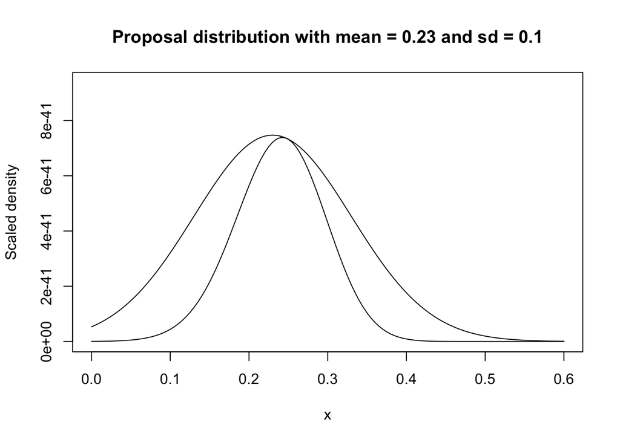

```r
alpha_prime <- optimize(f = function(y) proportion_function(target_distribution = target_distribution_pois,
                                                            proposal_distribution = dnorm, y = y,
                                                            mean = 0.23, sd = 0.1),
                        interval = c(0, 1), maximum = FALSE)

plot(seq(0,0.6,0.005),
     dnorm(seq(0,0.6,0.005), mean = 0.23, sd = 0.1)/alpha_prime$objective,
     type = 'l',
     xlim = c(0,0.6),
     ylim = c(0, 5/alpha_prime$objective),
     xlab = "x", ylab = "Scaled density", main = "Proposal distribution with mean = 0.23 and sd = 0.1"
     )
lines(seq(0,0.6,0.005), target_distribution_pois(seq(0,0.6,0.005)))
```

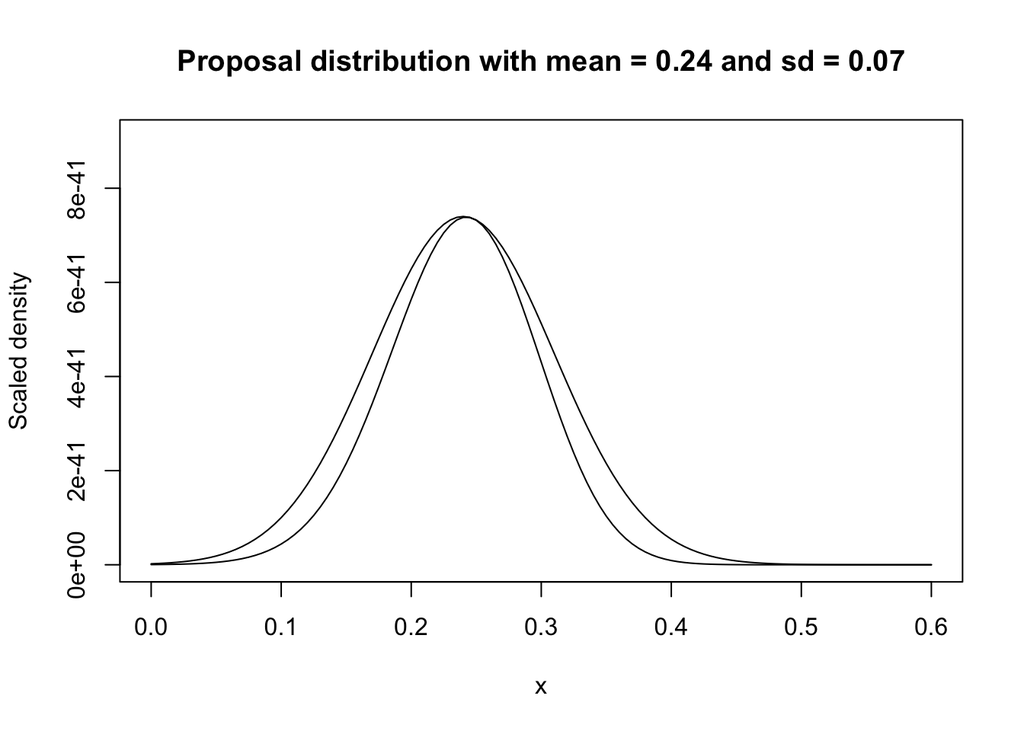

```r
alpha_prime <- optimize(f = function(y) proportion_function(target_distribution = target_distribution_pois,
                                                            proposal_distribution = dnorm, y = y,
                                                            mean = 0.24, sd = 0.07),
                        interval = c(0, 1), maximum = FALSE)

plot(seq(0,0.6,0.005),
     dnorm(seq(0,0.6,0.005), mean = 0.24, sd = 0.07)/alpha_prime$objective,
     type = 'l',
     xlim = c(0,0.6),
     ylim = c(0, 7/alpha_prime$objective),
     xlab = "x", ylab = "Scaled density", main = "Proposal distribution with mean = 0.24 and sd = 0.07"
     )
lines(seq(0,0.6,0.005), target_distribution_pois(seq(0,0.6,0.005)))
```

We see that the proposal distribution with mean = 0.24 and sd = 0.07 covers the target distribution well, so we choose these values. The optimal value of $\alpha'$ is calculated to be:

```r
alpha_prime$objective
```

```
## [1] 7.70203e+40
```

We save the identified values as they are and in a list for later use:

```r
proposal_mean <- 0.24
proposal_sd <- 0.07
alpha_p <- alpha_prime$objective
gaussian_envelope_parameters <- list(proposal_mean = proposal_mean, proposal_sd = proposal_sd, alpha_p = alpha_p)
```

We then implement a naive loop-based version of rejection sampling using this:

```r
gaussian_loop
```

```
## function (N, mu, sigma, alpha_prime)
## {
##     samples <- numeric(N)
##     rejection_count <- 0
##     for (i in 1:N) {
##         reject <- TRUE
##         while (reject) {
##             x0 <- rnorm(1, mean = mu, sd = sigma)
##             u <- runif(1)
##             target_x0 <- target_distribution_pois(x0)
##             proposal_x0 <- dnorm(x0, mean = mu, sd = sigma)
##             reject <- u > alpha_prime * target_x0/proposal_x0
##             if (reject) {
##                 rejection_count <- rejection_count + 1
##             }
##         }
##         samples[i] <- x0
##     }
##     alpha_hat <- N/(N + rejection_count)
##     return(list(samples = samples, rejection_count = rejection_count,
##         alpha_hat = alpha_hat))
## }
```

Note we can plot the theoretical distribution by estimating $\alpha$ as $\hat \alpha = \frac{N}{N + \text{rejection_count}}$ and then plotting the scaled target distribution with the estimated $\alpha$:

$$f(x) \approx \frac{\alpha'}{\hat
\alpha}q(x)$$

Plugging in the values of the mean, standard deviation, $\alpha'$ and $\hat \alpha$ we get the following samples:

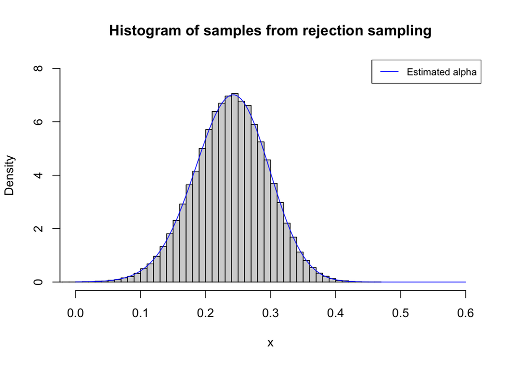

```r
N <- 100000
rejection_list <- gaussian_loop(N, proposal_mean, proposal_sd, alpha_p)
rejection_sample <- rejection_list$samples
n_rejections <- rejection_list$rejection_count
alpha_hat <- rejection_list$alpha_hat

hist(rejection_sample,
     probability = TRUE,
     breaks = 50, main = "Histogram of samples from rejection sampling",
     xlab = "x", ylab = "Density", xlim = c(0, 0.6), ylim = c(0, 8))
lines(seq(0,0.6,0.005),
      (alpha_prime$objective/alpha_hat) * target_distribution_pois(seq(0,0.6,0.005)),
      col = "blue")
legend("topright", legend = c("Estimated alpha"), col = c("blue"), lty = 1, cex = 0.8)
```

# Profiling and improving rejection sampler

Different implementations of the target density to optimize code - maybe benchmark before optimizing.

Estimated rejection probability is the gap between the envelope and the target density. Integrate difference

Plot difference between envelope and target distribution to make sure the difference is positive

Create S3 object gaussian envelope

# Adaptive rejection sampling algorithm with piecewise log-affine envelope

## Introduction

In the following we introduce a data-adaptive strategy to constructing a piecewise log-affine envelope. The strength of this approach is, that as long as the target distribution is log-concave, the envelope will be a good approximation of the target distribution. Hence, we do not have to ‘find’ a good envelope, but can construct it on the fly. The downside is that the algorithm is more computationally expensive than the previous rejection sampling algorithm, so it may not suitable or feasible for all problems.

## Brief theoretical introduction

Let $f$ be the target distribution as before. We seek to construct a suitable proposal distribution. The proposal distribution is defined on an open interval $I \subset \mathbb{R}$ partioned into $m$ non-empty intervals $I_1 = (z_0, z_1], \ldots, I_m = (z_{m-1},z_m]$. For suitable $a_i$ and $b_i$ we define the piecewise affine function

$$V(y) = \sum_{i = 1}^m (a_iy + b_i)
\mathbb{1}_{I_i}(y)$$
where $\mathbb{1}_{I_i}(y)$ is the indicator function of $I_i$. If

$$d = \int_{z_0}^{z_m} \exp (V(y)) dy
< \infty$$
then we can use a proposal distribution with a piecewise log-affine density

$$g(x) = \frac{1}{d} \exp(V(x))$$

The distribution function for $g$ is given by

$$G(x) = \int_{z_0}^x g(y) dy =
\frac{1}{d} \int_{z_0}^x \exp(V(y)) dy$$
We can sample from this distribution by inverting the distribution function and evaluating the inverse at a uniform random variable $u \sim U(0,1)$. To compute the inverse of $G(x)$ we need to do a few tricks which involves a bit of book keeping.

### Inverting the distribution function

Define for $i = 1,...,m$ the functions

$$H_i(x) = \int_{z_{i-1}}^x \exp(a_i z +
b_i) dz$$
and let $R_i = H_i(z_i)$ and $Q = \sum_{i = 1}^m R_i$. Then $d = Q_m$ and for $q \in (0,1)$ solving $G(x) = q$ is equivalent to solving

$$H_i(x) = dq - Q_{i-1}$$

### Implementation

We let $a_i = (\log (f(x_i)))' = \frac{f'(x_i)}{f(x_i)}$ and $b_i = \log(f(x_i)) - a_i x_i$. In this way, $a_i x + b_i$ is the tangent to $\log f(x)$ at $x_i$. By log-concavity we then have

$$\log(f(x)) \leq
\frac{f'(x_i)}{f(x_i)} (x- x_i) + \log(f(x_i)) = a_i x +
b_i$$
for $x \in I_i$. Thus

$$\log(f(x)) \leq V(x) = \sum_{i = 1}^m
(a_iy + b_i) \mathbb{1}_{I_i}(x)$$
and provided that $d < \infty$ the piecewise log-affine density proportional to $V(x)$ is a valid proposal distribution for rejection sampling from $f(x)$ with $\alpha' = 1$. We can tighten the envelope by choosing the $z_i$’s such that they are at the intersection of the lines $a_i x + b_i$ and $a_{i+1}x + b_{i+1}$. This is achieved by setting

$$z_i = \frac{b_{i+1} - b_i}{a_i -
a_{i+1}}$$
.

## Implementing the adaptive rejection sampler

We start by checking that target distribution (or something propoportaional) is in fact log-concave.

$$\log q(y) = \log \prod_{i = 1}^{100}
\exp(yz_ix_i - \exp(yx_i)) = \sum_{i = 1}^{100} (yz_ix_i -
\exp(yx_i))$$

$$\frac{d \log q(y)}{dy} = \sum_{i =
1}^{100} (z_ix_i - x_i \exp(yx_i))$$

Having the check in place we implement the adaptive rejection sampler

```r
log_target_dist <- log_target_distribution_pois
log_target_dist_diff <- log_target_distribution_diff_pois


length(adaptive_rejection_sampler(N = 250000,
                                  break_points = c(0.2,0.25,0.3),
                                  log_target_dist, log_target_dist_diff))
```

```
## [1] 201184
```

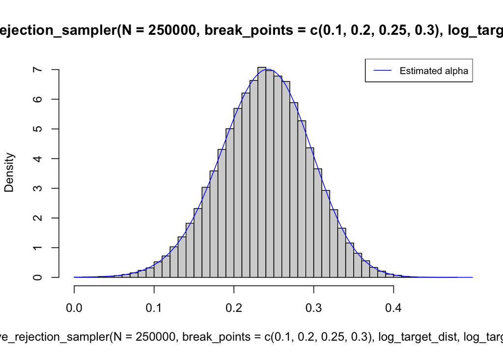

```r
hist(adaptive_rejection_sampler(N = 250000, break_points = c(0.1,0.2,0.25,0.3),
                                log_target_dist, log_target_dist_diff), probability = TRUE, breaks = 50)
lines(seq(0,0.6,0.005),
      (alpha_prime$objective/alpha_hat) * target_distribution_pois(seq(0,0.6,0.005)),
      col = "blue")
legend("topright", legend = c("Estimated alpha"), col = c("blue"), lty = 1, cex = 0.8)
```